# R Notebook

```r
library(tidyverse)
library(janitor)
```

| tu_score | employed | age | accepted |
| --- | --- | --- | --- |
| 433 | TRUE | 28 | TRUE |
| 93 | TRUE | 52 | FALSE |
| 368 | FALSE | 63 | FALSE |
| 665 | TRUE | 42 | TRUE |
| 687 | TRUE | 38 | TRUE |
| 594 | TRUE | 27 | FALSE |

TU score - TransUnion score ~= a credit score from 0:710

# Binary target variables

Target Variable <- Accepted

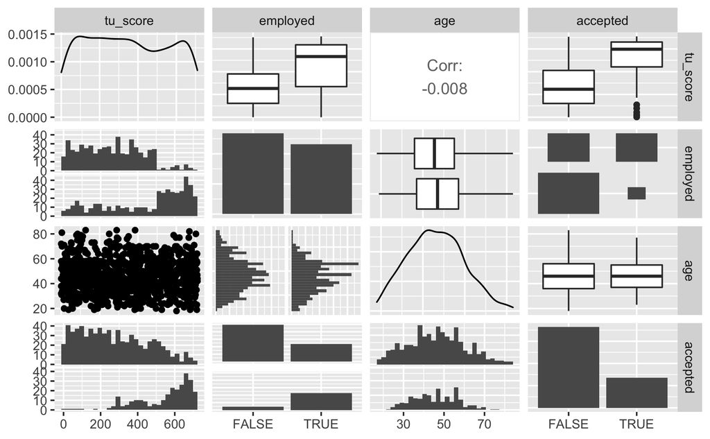

# Plot TU score against accepted

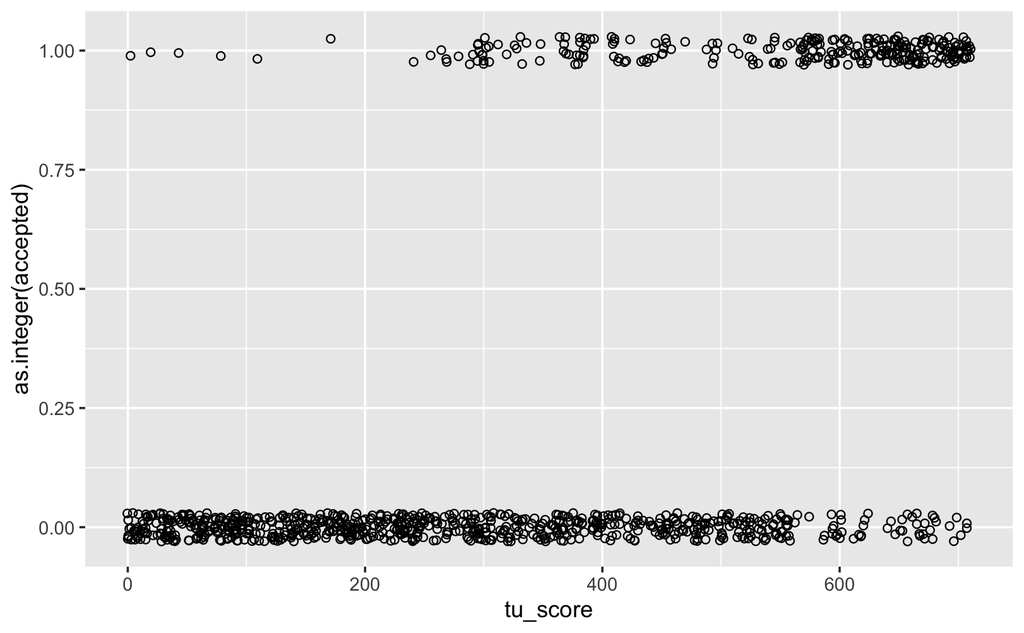

# Try linear regression

```r
library(modelr)
```

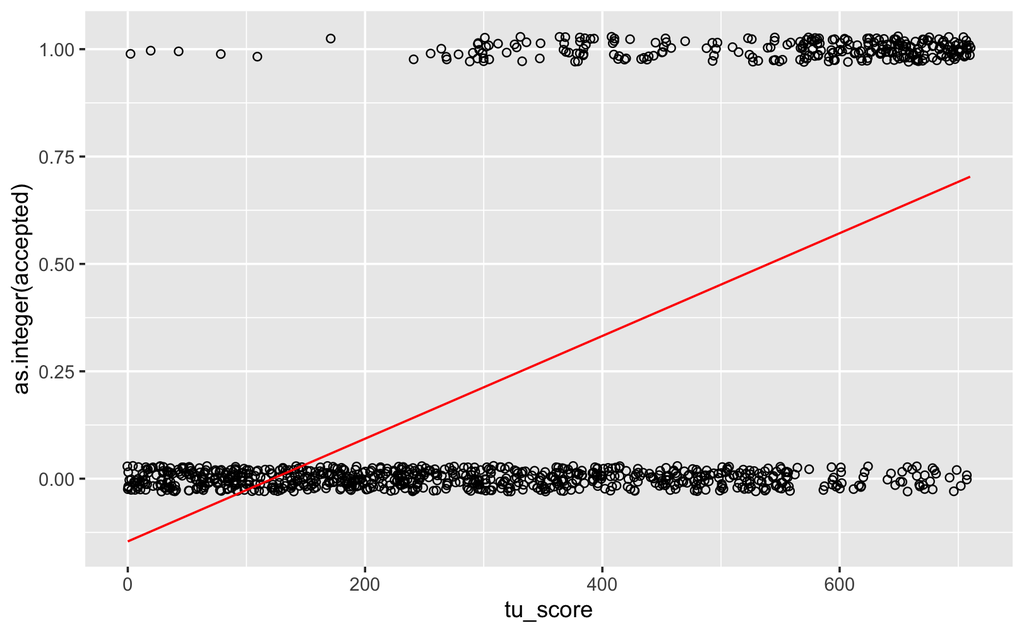

We can’t have a negative probability! Empirical probability of being accepted for a mortgage with a TU score of 594 - 3/5, 0.6.

| tu_score | employed | age | accepted |
| --- | --- | --- | --- |
| 594 | TRUE | 27 | FALSE |
| 594 | TRUE | 47 | FALSE |
| 594 | TRUE | 33 | TRUE |
| 594 | TRUE | 36 | TRUE |
| 594 | TRUE | 45 | TRUE |

# Logistic probability

Lets us predict the probability of a binary outcome. The logistic function provides a far better model for the estimated probability of ‘success’ on a binary outcome. Cannot go below zero

```r
logistic <- function(x, L = 1, k = 1, x0 = 0 ){
  return(L / (1 + exp(-k * (x - x0))))
}
```

## L = maximum height of curve

Increasing maximum height of curve affects how steeply the curve changes ## x0 = Sigmoid’s Midpoint x0 affects the location of the ‘step’ in the function. To be precise, f(x0)=0.5, so positive values shift f(x) to the right, and negative values shift it to the left. Affects where the curve starts and stops. ## k = the logistic growth rate or steepness of the curve. Increasing k means we spend more time at our highest and lowest points and have a steeper line between highest and lowest. Negative k, when a value is high we want low likelihood (e.g. higher debt -> lower likelihood of mortgage)

# Logit function

ln(odds of x) = b0 + b1 * x

The log of the fitted pobability of x = log of the odds of success = log of the fitted probability divided by 1 minus the fitted probability

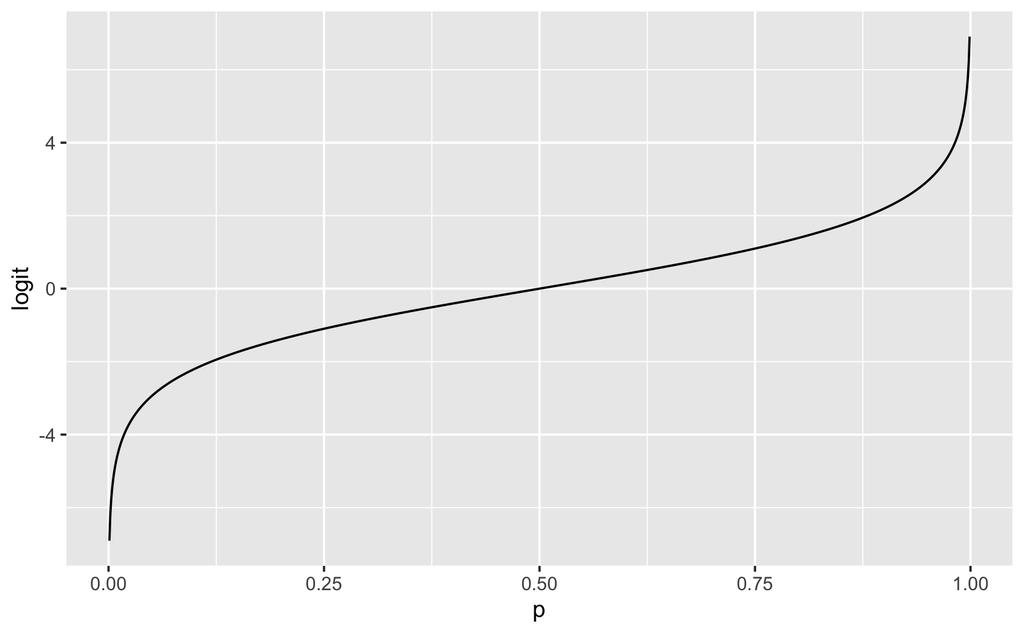

```r
logit <- function(x){
  return(log(x/(1-x)))
}

logit_data <- tibble(p = seq(0.001, 0.999, 0.001)) %>%
  mutate(logit = logit(p))

ggplot(logit_data, aes(x = p, y = logit)) +
  geom_line()
```

Calling logit on our p values. y = 0:1 (the default values for L) logit 0 crosses p at 0.5 (the default value for sigmoid centre)

# Building a logistic regression model

The argument family = binomial(link = ‘logit’) is what tells glm() to perform a logistic regression.

```r
mortgage_data_logreg_model <- glm(accepted ~ tu_score, data = mortgage_data, family = binomial(link = 'logit'))
mortgage_data_logreg_model
```

```
Call:  glm(formula = accepted ~ tu_score, family = binomial(link = "logit"),
    data = mortgage_data)

Coefficients:
(Intercept)     tu_score
  -4.575035     0.008475

Degrees of Freedom: 999 Total (i.e. Null);  998 Residual
Null Deviance:      1170
Residual Deviance: 792.1    AIC: 796.1
```

Plot the estimated probability as a function of tu score

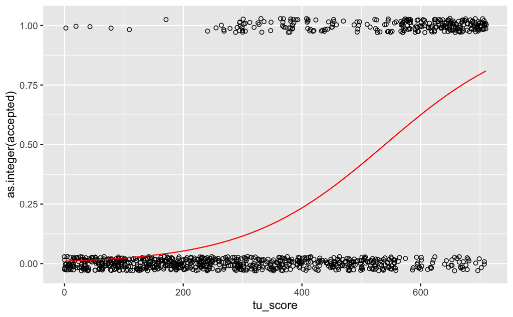

```r
predict_log <- tibble(tu_score = seq(0, 710, 1)) %>%
              # argument type = 'response' is used in glm models
              add_predictions(mortgage_data_logreg_model, type = 'response')
score_plot +
   geom_line(data = predict_log, aes(x = tu_score , y = pred), col = 'red')
```

# Interpreting b1 for continuous predictors

See prediction at 594

| tu_score | pred |
| --- | --- |
| 594 | 0.6127971 |

Let’s get the odds of having an accepted application at a particular tu_score, say at a value 594.

```r
odds_at_594 <- tibble(tu_score = 594) %>%
  add_predictions(mortgage_data_logreg_model, type='response') %>%
  mutate(odds = pred/(1-pred)) %>%
  select(odds)

odds_at_594
```

| odds |
| --- |
| 1.582625 |

```r
NA
```

This is approximately 3-to-2 in favour of success.

How do these odds change if we increase tu_score by, say, 50 points to 644? The maths above tells us the odds will change by a factor eb1×change in x=eb1×50. So we need to get coefficient btu_score from mortgage_data_logreg_model and then use it to work out the factor multiplying the odds.

| estimate |
| --- |
| 2.417739 |

Big increase! The odds are now nearly 5-to-2 in favour. Let’s check if this is correct by getting the probability of acceptance at 644 and calculating the odds directly.

```r
tibble(tu_score = 644) %>%
  add_predictions(mortgage_data_logreg_model, type='response') %>%
  mutate(odds = pred/(1-pred)) %>%
  select(odds)
```

| odds |
| --- |
| 2.417739 |

Odds with a decrease of 50

| estimate |
| --- |
| 1.035969 |

# Adding variables

| term | estimate | std_error | statistic | p_value |
| --- | --- | --- | --- | --- |
| (Intercept) | -4.628539329 | 0.4303343969 | -10.7556806 | 5.572114e-27 |
| tu_score | 0.006730118 | 0.0005692479 | 11.8228250 | 2.975086e-32 |
| employedTRUE | 1.480341044 | 0.2114793584 | 6.9999316 | 2.560875e-12 |
| age | -0.001260001 | 0.0070633577 | -0.1783856 | 8.584202e-01 |

| null_deviance | df_null | log_lik | aic | bic | deviance | df_residual | nobs |
| --- | --- | --- | --- | --- | --- | --- | --- |
| 1170.476 | 999 | -369.9771 | 747.9542 | 767.5853 | 739.9542 | 996 | 1000 |

# Interpreting b1/coefficient/gradient for categorical predictors

Odds factor = e^b1 * difference

Because we are dealing with a binary predictor, our difference is always 1 so odds_factors = e^b1

| estimate |
| --- |
| 4.394444 |

Employment -> 4.39 times more likely to be accepted for a mortgage.